# Problem Set_04

Miguel Desmarais (21421145)

version April 25, 2018

### Problem set 04 “Fine-scale phylogenetic architecture”

#### Learning objectives:

- Gain experience estimating diversity within a hypothetical microbial community

#### Part 1: Description and enumeration

Obtain a collection of “microbial” cells from “seawater”. The cells were concentrated from different depth intervals by a marine microbiologist travelling along the Line-P transect in the northeast subarctic Pacific Ocean off the coast of Vancouver Island British Columbia.

Sort out and identify different microbial “species” based on shared properties or traits. Record your data in this Rmarkdown using the example data as a guide.

Once you have defined your binning criteria, separate the cells using the sampling bags provided. These operational taxonomic units (OTUs) will be considered separate “species”. This problem set is based on content available at [What is Biodiversity](http://cnx.org/content/m12179/latest/).

##### Complete microbial community:

```r
library(kableExtra)
library(knitr)
library(tidyverse)

fullcommunity = read.csv("fullcommunity.csv")

fullcommunity %>%
  kable("html") %>%
  kable_styling(bootstrap_options = "striped", font_size = 10, full_width = F)
```

| number | name | characteristics | occurences |
| --- | --- | --- | --- |
| 1 | orangebear | orange gummy bear | 14 |
| 2 | pinkbear | pink gummy bear | 16 |
| 3 | yellowbear | yellow gummy bear | 16 |
| 4 | whitebear | white gummy bear | 16 |
| 5 | redbear | red gummy bear | 10 |
| 6 | green bear | green gummy bear | 18 |
| 7 | pinksolidbear | solid pink gummy bears | 1 |
| 8 | redsolidbear | solid red gummy bears | 1 |
| 9 | jellybeanyellow | yellow jelly bean | 26 |
| 10 | jellybeanorange | orange jelly bean | 31 |
| 11 | jellybeanpink | pink jelly bean | 37 |
| 12 | jellybeangreen | green jelly bean | 33 |
| 13 | jellybeanred | red jellybean | 38 |
| 14 | jellyrodsyellow | long yellow jelly rods | 3 |
| 15 | jellyrodsorange | long orange jelly rods | 1 |
| 16 | jellyrodsred | long red jelly rods | 2 |
| 17 | jellyrodsblack | long black jelly rods | 1 |
| 18 | redswirl | red swirl | 1 |
| 19 | blueswirl | blue swirl | 2 |
| 20 | ovalyellow | yellow oval | 1 |
| 21 | redfilamentous | red, long string-like | 5 |
| 22 | orangespider | orange spider-shaped | 2 |
| 23 | pinkspider | pink spider-shape | 3 |
| 24 | purplespider | purple spider-shape | 1 |
| 25 | coke-bottlered | red coke bottle | 1 |
| 26 | cokebottlepink | pink coke bottle | 1 |
| 27 | cokebottleyellow | yellow coke bottle | 1 |
| 28 | kissessilver | silver kisses | 15 |
| 29 | bigbluebrick | large blue brick | 1 |
| 30 | bigyellowbrick | large yellow brick | 1 |
| 31 | bigpinkbrick | large pink brick | 1 |
| 32 | smallbluebrick | small blue brick | 3 |
| 33 | small yellow brick | small yellow brick | 3 |
| 34 | smallgreenbrick | small green brick | 2 |
| 35 | smallpinkbrick | small pink brick | 6 |
| 36 | biggreen | large round green jelly | 5 |
| 37 | bigpurple | large round purple jelly | 3 |
| 38 | bigred | large round red jelly | 7 |
| 39 | bigorange | large round orange jelly | 5 |
| 40 | bigyellow | large round yellow jelly | 3 |
| 41 | m&morange | orange m&m | 59 |
| 42 | m&mgreen | green m&m | 30 |
| 43 | m&mred | red m&m | 27 |
| 44 | m&myellow | yellow m&m | 34 |
| 45 | m&mbrown | brown m&m | 30 |
| 46 | m&mblue | blue m&m | 60 |
| 47 | skittlesyellow | yellow skittle | 34 |
| 48 | skittlesorange | orange skittle | 39 |
| 49 | skittlered | red skittle | 30 |
| 50 | skittlebrown | brown skittle | 30 |
| 51 | skittlegreen | green skittle | 42 |

##### Microbial community in subsample:

- **Construct a table listing each species, its distinguishing characteristics, the name you have given it, and the number of occurrences of the species in the collection.**

```r
mycommunity = read.csv("mycommunity.csv")

mycommunity %>%
  kable("html") %>%
  kable_styling(bootstrap_options = "striped", font_size = 10, full_width = F)
```

| number | name | characteristics | occurences |
| --- | --- | --- | --- |
| 1 | orangebear | orange gummy bear | 1 |
| 2 | pinkbear | pink gummy bear | 2 |
| 3 | yellowbear | yellow gummy bear | 5 |
| 4 | whitebear | white gummy bear | 5 |
| 5 | greenbear | green gummy bear | 4 |
| 6 | jellyrodsyellow | long yellow jelly rods | 6 |
| 7 | jellyrodsorange | long orange jelly rods | 9 |
| 8 | jellyrodsred | long red jelly rods | 5 |
| 9 | redswirl | red swirl | 1 |
| 10 | blueswirl | blue swirl | 1 |
| 11 | ovalyellow | yellow oval | 1 |
| 12 | redfilamentous | red, long string-like | 2 |
| 13 | cokebottlepink | pink coke bottle | 1 |
| 14 | kissessilver | silver kisses | 7 |
| 15 | smallbluebrick | small blue brick | 1 |
| 16 | smallyellowbrick | small yellow brick | 1 |
| 17 | smallpinkbrick | small pink brick | 1 |
| 18 | biggreen | large round green jelly | 1 |
| 19 | bigpurple | large round purple jelly | 1 |
| 20 | bigred | large round red jelly | 1 |
| 21 | bigorange | large round orange jelly | 1 |
| 22 | m&morange | orange m&m | 8 |
| 23 | m&mgreen | green m&m | 9 |
| 24 | m&mred | red m&m | 3 |
| 25 | m&myellow | yellow m&m | 10 |
| 26 | m&mbrown | brown m&m | 7 |
| 27 | m&mblue | blue m&m | 8 |
| 28 | skittlesyellow | yellow skittle | 5 |
| 29 | skittlesorange | orange skittle | 9 |
| 30 | skittlered | red skittle | 5 |
| 31 | skittlebrown | brown skittle | 1 |
| 32 | skittlegreen | green skittle | 10 |

- **Ask yourself if your collection of microbial cells from seawater represents the actual diversity of microorganisms inhabiting waters along the Line-P transect. Were the majority of different species sampled or were many missed?**

My collection of microbial cells from seawater does not fully represent the actual diversity of microorganisms inhabiting waters along Line-P transect. Only 32 out of the 51 species were identified in my sample compared to the full community.

#### Part 2: Collector’s curve

- **Create a collector’s curve for your sample (not the entire original community).**

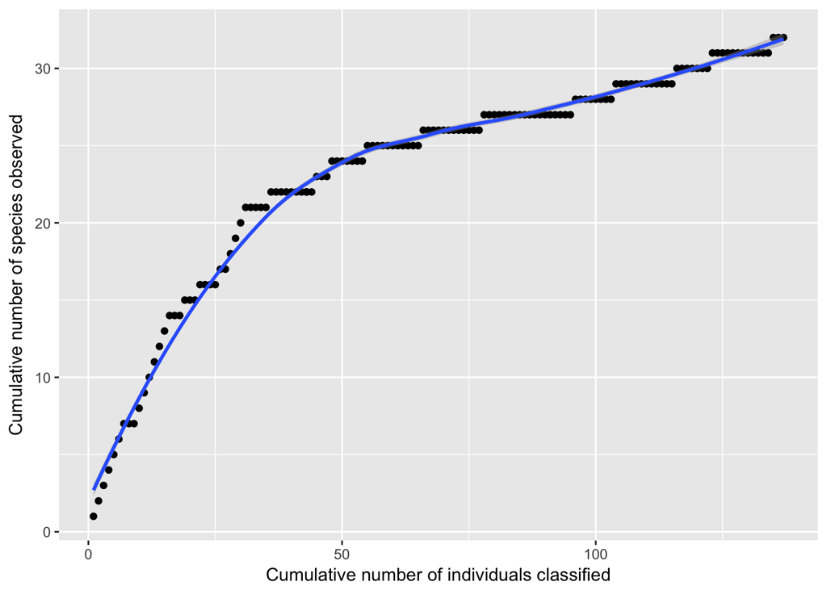

```r
library(ggplot2)

collector= read.csv("collector.csv")

ggplot(collector, aes(x=x, y=y)) +
  geom_point() +
  geom_smooth() +
  labs(x="Cumulative number of individuals classified", y="Cumulative number of species observed")
```

- **Does the curve flatten out? If so, after how many individual cells have been collected?**

The collector’s curve for my sample does not flatten out.

- **What can you conclude from the shape of your collector’s curve as to your depth of sampling?**

I can conclude from the shape of my collector’s curve that the depth of my sampling is not the greatest. Since the curve does not flatten out, more species would most likely be found if more sampling was done. The collector’s curve and this conclusion agree with the difference in the number of species found in my sample and in the full community (32 and 51, respectively).

#### Part 3: Diversity estimates (alpha diversity)

##### Diversity: Simpson Reciprocal Index

$\frac{1}{D}$ where $D = \sum p_i^2$

$p_i$ = the fractional abundance of the $i^{th}$ species

The higher the value is, the greater the diversity. The maximum value is the number of species in the sample, which occurs when all species contain an equal number of individuals. Because the index reflects the number of species present (richness) and the relative proportions of each species within a community (evenness), this is a diversity metric. Consider that a community can have the same number of species (equal richness) but manifest a skewed distribution in the proportion of each species (unequal evenness), which would result in different diversity values.

- **What is the Simpson Reciprocal Index for your sample?**

```r
orangebear = 1/132
pinkbear = 2/132
yellowbear = 5/132
whitebear = 5/132
greenbear = 4/132
jellyrodsyellow = 6/132
jellyrodsorange = 9/132
jellyrodsred = 5/132
redswirl = 1/132
blueswirl = 1/132
ovalyellow = 1/132
redfilamentous = 2/132
cokebottlepink = 1/132
kissessilver = 7/132
smallbluebrick = 1/132
smallyellowbrick = 1/132
smallpinkbrick = 1/132
biggreen = 1/132
bigpurple = 1/132
bigred = 1/132
bigorange = 1/132
mnmorange = 8/132
mnmgreen = 9/132
mnmred = 3/132
mnmyellow= 10/132
mnmbrown = 7/132
mnmblue = 8/132
skittlesyellow = 5/132
skittlesorange = 9/132
skittlered = 5/132
skittlebrown = 1/132
skittlegreen = 10/132

1 / (orangebear^2 + pinkbear^2 + yellowbear^2 + whitebear^2 +
greenbear^2 + jellyrodsyellow^2 + jellyrodsorange^2 + jellyrodsred^2 + redswirl^2 + blueswirl^2 + ovalyellow^2 + redfilamentous^2 + cokebottlepink^2 + kissessilver^2 + smallbluebrick^2 + smallyellowbrick^2 + smallpinkbrick^2 + biggreen^2 + bigpurple^2 + bigred^2 + bigorange^2 + mnmorange^2 + mnmgreen^2 + mnmred^2 + mnmyellow^2 + mnmbrown^2 + mnmblue^2 + skittlesyellow^2 + skittlesorange^2 + skittlered^2 + skittlebrown^2 + skittlegreen^2)
```

```
## [1] 19.89041
```

- **What is the Simpson Reciprocal Index for your original total community?**

Calculated on spreadsheet: 23.1744939

##### Richness: Chao1 richness estimator

Another way to calculate diversity is to estimate the number of species that are present in a sample based on the empirical data to give an upper boundary of the richness of a sample. Here, we use the Chao1 richness estimator.

$S_{chao1} = S_{obs} + (\frac{a^2}{2b})$

$S_{obs}$ = total number of species observed a = species observed once b = species observed twice or more

- **What is the chao1 estimate for your sample?**

$S_{chao1}$ =

```r
32 + 13^2/(2*19)
```

```
## [1] 36.44737
```

- **What is the chao1 estimate for your original total community?**

$S_{chao1}$ =

```r
51 + 13^2/(2*38)
```

```
## [1] 53.22368
```

#### Part 4: Alpha-diversity functions in R

```r
library(tidyverse)
library(dplyr)
library(vegan)

mycommunity_diversity =
  mycommunity %>%
  select(name, occurences) %>%
  spread(name, occurences)

fullcommunity_diversity =
  fullcommunity %>%
  select(name, occurences) %>%
  spread(name, occurences)

mycommunity_diversity
```

```
##   biggreen bigorange bigpurple bigred blueswirl cokebottlepink greenbear
## 1        1         1         1      1         1              1         4
##   jellyrodsorange jellyrodsred jellyrodsyellow kissessilver m&mblue
## 1               9            5               6            7       8
##   m&mbrown m&mgreen m&morange m&mred m&myellow orangebear ovalyellow
## 1        7        9         8      3        10          1          1
##   pinkbear redfilamentous redswirl skittlebrown skittlegreen skittlered
## 1        2              2        1            1           10          5
##   skittlesorange skittlesyellow smallbluebrick smallpinkbrick
## 1              9              5              1              1
##   smallyellowbrick whitebear yellowbear
## 1                1         5          5
```

```r
fullcommunity_diversity
```

```
##   bigbluebrick biggreen bigorange bigpinkbrick bigpurple bigred bigyellow
## 1            1        5         5            1         3      7         3
##   bigyellowbrick blueswirl coke-bottlered cokebottlepink cokebottleyellow
## 1              1         2              1              1                1
##   green bear jellybeangreen jellybeanorange jellybeanpink jellybeanred
## 1         18             33              31            37           38
##   jellybeanyellow jellyrodsblack jellyrodsorange jellyrodsred
## 1              26              1               1            2
##   jellyrodsyellow kissessilver m&mblue m&mbrown m&mgreen m&morange m&mred
## 1               3           15      60       30       30        59     27
##   m&myellow orangebear orangespider ovalyellow pinkbear pinksolidbear
## 1        34         14            2          1       16             1
##   pinkspider purplespider redbear redfilamentous redsolidbear redswirl
## 1          3            1      10              5            1        1
##   skittlebrown skittlegreen skittlered skittlesorange skittlesyellow
## 1           30           42         30             39             34
##   small yellow brick smallbluebrick smallgreenbrick smallpinkbrick
## 1                  3              3               2              6
##   whitebear yellowbear
## 1        16         16
```

- **What are the Simpson Reciprocal Indices for your sample and community using the R function?**

Simpson Reciprocal Index for my sample:

```r
diversity(mycommunity_diversity, index="invsimpson")
```

```
## [1] 19.89041
```

Simpson Reciprocal Index for community:

```r
diversity(fullcommunity_diversity, index="invsimpson")
```

```
## [1] 23.17449
```

The Simpson Reciprocal Indices values obtained from the R function do match the value calaculated for my sample and community.

- **What are the chao1 estimates for your sample and community using the R function? Verify that these values match your previous calculations.**

Chao1 richness estimate for my sample:

```r
specpool(mycommunity_diversity)
```

```
##     Species chao chao.se jack1 jack1.se jack2 boot boot.se n
## All      32   32       0    32        0    32   32       0 1
```

Chao1 richness estimate for community:

```r
specpool(fullcommunity_diversity)
```

```
##     Species chao chao.se jack1 jack1.se jack2 boot boot.se n
## All      51   51       0    51        0    51   51       0 1
```

The Chao1 R function values do not matched my calculated value for my sample and community. It seems like the R function uses a different way of calculating Chao1 in which the total number of species observed is the chao1 value. Therefore, my calculated Chao1 values are slightly higher for both my sample and the community.

#### Part 5: Concluding activity

If you are stuck on some of these final questions, reading the [Kunin et al. 2010](https://www.ncbi.nlm.nih.gov/pubmed/19725865) and [Lundin et al. 2012](https://www.ncbi.nlm.nih.gov/pubmed/23760801) papers may provide helpful insights.

- **How does the measure of diversity depend on the definition of species in your samples?**

The measure of diversity, alpha diversity in this case, directly depends on the definition of species in my sample and community. Since both the Simpson Reciprocal Indices value and the Chao1 value are essentially based, in different ways, on the total number of species observed, changing the definition of species will have an effect on the number of species observed and alpha diversity.

For example, many studies use the 97% identity threshold value to definite species. Raising this value to 99% would result in more species observed in a sample (overestimating diversity) while lowering this threshold to 95%, for example, would results in more “identical” sequences and therefore less species observed in a sample (underestimating diversity).

- **Can you think of alternative ways to cluster or bin your data that might change the observed number of species?**

Binning or clustering data based on the GC content, codon usage or percent identity will most likely result in a different number of species observed in a sample since these methods are based on different sequence characteristics.

- **How might different sequencing technologies influence observed diversity in a sample?**

Inflated diversity have been previously associated with pyrosequencing errors. Sanger, a sequencing technology with a relatively low error rate, has shown a constant overestimation of diversity. Therefore, sequencing technologies with a higher base calling/sequencing error rate such as PacBio or Oxford Nanopore will most likely result in much more species observed in a sample. This is due to the potential introduction of wrong bases in a certain DNA sequence. This may in turn lead to the sequence falling bellow he 97% identity threshold and therefore being categorized as a different and new species observed in the sample.